[figure not shown]

```python
%matplotlib inline
from IPython.core.display import Image, display
from __future__ import print_function
display(Image('C://Users//Dar1//Documents//she_codes//python//she codes logo big python.png',
              width=600, height=200))
```

# Customization of box-plots in different axes

Author: Dar Lador

You’ve learned how create a box plot in python and how to change colors of boxes, whiskers, caps and the median. However, how would you customize 4 different subplots in the same figure?

```
Fig.1 | Figure with 4 sub-plots
```

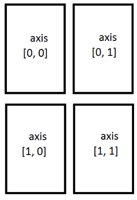

```python
print("Fig.1 | Figure with 4 sub-plots")
display(Image('C://Users//Dar1//Documents//she_codes//python//subplots4.png',
              width=200, height=100))
```

The axes are shown in Fig.1 are not necessarily contain the same plot type. In this notebook I’m going to show you how to customize each sub-plot in different axis. In the end of this notebook you’ll get an exercise to implement what you’ve learned.

```python
import numpy as np
import matplotlib.pyplot as plt
from textwrap import wrap
import matplotlib.ticker as plticker
```

Create a figure with 2 rows and 2 columns as shown in Fig.1

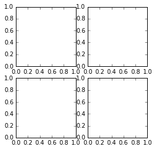

```python
fig, axes = plt.subplots(nrows=2, ncols=2,
                         figsize=(4, 4), dpi=100)
```

Add a box-plot to the top left axis by specify the location (Fig.1). I pass three arguments in boxplot() function:

| Argument | Meaning |
| --- | --- |
| my_data | x data |
| labels = labels_all | labels for all the data |
| patch_artist = True | enable further customizaton |
| notch = True | *notches are used to compare groups; |

*If the notches of two boxes do not overlap, this is a strong evidence that the medians are different.

Data for the top left axis:

```python
# creating data
np.random.seed(10)
d10 = np.random.normal(100, 10, 200)
d20 = np.random.normal(80, 30, 200)
d30 = np.random.normal(90, 20, 200)
d40 = np.random.normal(70, 25, 200)

# combine these different arrays into a list
my_data0 = [d10, d20, d30, d40]

#create labels for all the data
labels_all = ['A', 'B', 'C', 'D']

ax0 = axes[0, 0].boxplot(my_data0, labels = labels_all,
                         patch_artist=True, notch=True)
axes[0, 0].set_title('1st boxplot', fontsize=10)
```

Add another box plot to the top right axis (using the same labels as before):

```python
# creating data
np.random.seed(10)
d11 = np.random.normal(50, 10, 90)
d21 = np.random.normal(40, 10, 90)
d31 = np.random.normal(30, 10, 90)
d41 = np.random.normal(20, 5, 90)

# combine these different arrays into a list
my_data1 = [d11, d21, d31, d41]

ax1 = axes[0, 1].boxplot(my_data1, labels = labels_all,
                         patch_artist=True, notch=True)
axes[0, 1].set_title('2nd boxplot', fontsize=10)
```

Add the last box plot to the bottom left axis (using the same labels as before):

```python
# creating data
np.random.seed(10)
d12 = np.random.normal(100, 10, 200)
d22 = np.random.normal(80, 30, 200)
d32 = np.random.normal(90, 20, 200)
d42 = np.random.normal(70, 25, 200)

# combine these different arrays into a list
my_data2 = [d12, d22, d32, d42]

ax2 = axes[1, 0].boxplot(my_data1, labels = labels_all,
                         patch_artist=True, notch=True)
axes[1, 0].set_title('3rd boxplot', fontsize=10)
```

For the last axis I'll create a bar plot. Note I imported wrap from textwrap in order to wrap the title of this sub-plot.

```python
N = 3
menMeans = (20, 35, 30)
menStd = (2, 3, 4)

ind = np.arange(N)  # the x locations for the groups
width = 0.35       # the width of the bars

rects1 = axes[1,1].bar(ind, menMeans, width, color='#1b9e77',
                       yerr=menStd,nerror_kw = dict(ecolor='#7570b3',
                                                    lw=1,
                                                    capsize=2,
                                                    capthick=1))

womenMeans = (25, 32, 34)
womenStd = (3, 5, 2)
rects2 = axes[1,1].bar(ind + width, womenMeans, width,
                       color='#b2df8a', yerr=womenStd,
                      error_kw = dict(ecolor='#7570b3',
                                      lw=1,
                                      capsize=2,
                                      capthick=1))

# add axes ticks
axes[1,1].set_xticks(ind + width)
axes[1,1].set_xticklabels(('G1', 'G2', 'G3'))

# add legend and set a fixed y axis
axes[1,1].legend((rects1[0], rects2[0]), ('Men', 'Women'),
                 fontsize=8, bbox_to_anchor=(1.05, 1),
                 loc=2, borderaxespad=0.)
axes[1,1].set_ylim([0,45])

def autolabel(rects):
    # attach some text labels
    for rect in rects:
        height = rect.get_height()
        axes[1,1].text(rect.get_x() + rect.get_width()/2.,
                       1.05*height, '%d' % int(height),
                ha='center', va='bottom', fontsize=8)

autolabel(rects1)
autolabel(rects2)

axes[1, 1].set_title('\n'.join(wrap('Surprise! This is a barplot!',
                                    19)), fontsize=10)
```

Note our bar plot is already colored, so we just need to style ax0, ax1 and ax2

```python
for a in [ax0, ax1, ax2]:
    for box in a['boxes']:
        plt.setp(box, color='#7570b3', linewidth=1)
        box.set( facecolor = '#1b9e77' )
    plt.setp(a['whiskers'], color='#7570b3')
    plt.setp(a['caps'], color='#7570b3')
    for flier in a['fliers']:
        flier.set(marker='o', markerfacecolor='#e7298a',
                    markeredgecolor = '#e7298a', alpha=0.5)
    plt.setp(a['medians'], color='#b2df8a', linewidth=2)
```

Add a title, adjust the subplots and show the figure.

```python
fig.suptitle("Ugly customized boxplots with a barplot", y=1.02)
fig.subplots_adjust(hspace=0.5)
plt.show()
```

#### Full code

```
Fig.2 | Customized boxplots with different axes
```

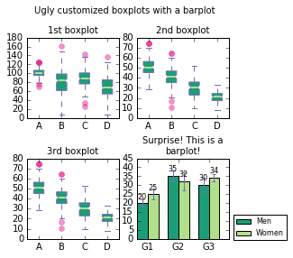

```python
print('Fig.2 | Customized boxplots with different axes')
fig, axes = plt.subplots(nrows=2, ncols=2, figsize=(4, 4),
                         dpi=100)

#ax0
np.random.seed(10)
d10 = np.random.normal(100, 10, 200)
d20 = np.random.normal(80, 30, 200)
d30 = np.random.normal(90, 20, 200)
d40 = np.random.normal(70, 25, 200)
my_data0 = [d10, d20, d30, d40]
labels_all = ['A', 'B', 'C', 'D']
ax0 = axes[0, 0].boxplot(my_data0, labels = labels_all,
                         patch_artist=True, notch=True)
axes[0, 0].set_title('1st boxplot', fontsize=10)

#ax1
np.random.seed(10)
d11 = np.random.normal(50, 10, 90)
d21 = np.random.normal(40, 10, 90)
d31 = np.random.normal(30, 10, 90)
d41 = np.random.normal(20, 5, 90)
my_data1 = [d11, d21, d31, d41]
ax1 = axes[0, 1].boxplot(my_data1, labels = labels_all,
                         patch_artist=True, notch=True)
axes[0, 1].set_title('2nd boxplot', fontsize=10)

#ax2
np.random.seed(10)
d12 = np.random.normal(100, 10, 200)
d22 = np.random.normal(80, 30, 200)
d32 = np.random.normal(90, 20, 200)
d42 = np.random.normal(70, 25, 200)
my_data2 = [d12, d22, d32, d42]
ax2 = axes[1, 0].boxplot(my_data1, labels = labels_all,
                         patch_artist=True, notch=True)
axes[1, 0].set_title('3rd boxplot', fontsize=10)

#ax3
N = 3
menMeans = (20, 35, 30)
menStd = (2, 3, 4)
ind = np.arange(N)
width = 0.35
rects1 = axes[1,1].bar(ind, menMeans, width,
                       color='#1b9e77', yerr=menStd,
                      error_kw = dict(ecolor='#7570b3',
                                      lw=1,
                                      capsize=2,
                                      capthick=1))
womenMeans = (25, 32, 34)
womenStd = (3, 5, 2)
rects2 = axes[1,1].bar(ind + width, womenMeans, width,
                       color='#b2df8a', yerr=womenStd,
                      error_kw = dict(ecolor='#7570b3',
                                      lw=1,
                                      capsize=2,
                                      capthick=1))
axes[1,1].set_xticks(ind + width)
axes[1,1].set_xticklabels(('G1', 'G2', 'G3'))
axes[1,1].legend((rects1[0], rects2[0]), ('Men', 'Women'),
                 fontsize=8, bbox_to_anchor=(1.05, 0.3),
                 loc=2, borderaxespad=0.)
axes[1,1].set_ylim([0,45])
def autolabel(rects):
    for rect in rects:
        height = rect.get_height()
        axes[1,1].text(rect.get_x() + rect.get_width()/2., 1.05*height,
                '%d' % int(height),
                ha='center', va='bottom', fontsize=8)
autolabel(rects1)
autolabel(rects2)
axes[1, 1].set_title('\n'.join(wrap('Surprise! This is a barplot!',
                                    19)), fontsize=10)

#Customize
for a in [ax0, ax1, ax2]:
    for box in a['boxes']:
        plt.setp(box, color='#7570b3', linewidth=1)
        box.set( facecolor = '#1b9e77' )
    plt.setp(a['whiskers'], color='#7570b3')
    plt.setp(a['caps'], color='#7570b3')
    for flier in a['fliers']:
        flier.set(marker='o', markerfacecolor='#e7298a',
                    markeredgecolor = '#e7298a', alpha=0.5)
    plt.setp(a['medians'], color='#b2df8a', linewidth=2)

fig.suptitle("Ugly customized boxplots with a barplot", y=1.02)
fig.subplots_adjust(hspace=0.5)
plt.show()
```

# Box-plot exercise

Author: *Dar Lador*

In this exercise I use some published data from a real biological research. However, **no biology background is needed** to complete this exercise.

### Reference

> Kaur K., et al. (2016) Phe362Tyr in AChE: A Major Factor Responsible for Azamethiphos Resistance in Lepeophtheirus salmonis in Norway. *PLoS ONE* 11(2): e0149264. doi:10.1371/journal.pone.0149264 block

### Instructions

#### Download the exercise and define a figure

- Download the [exercise](https://drive.google.com/open?id=0B9crmgoWupXkd1RTWWF6SDhIa3c) and place it in your PyCharm project folder.
- Line 21: define a figure contains 6 sub-plots (3 columns and 2 rows) and dpi=100 (see **Fig.3**).

```
Fig.3 | Figure with 6 sub-plots
```

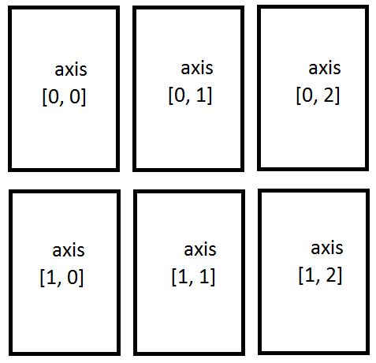

```python
print("Fig.3 | Figure with 6 sub-plots")
display(Image('C://Users//Dar1//Documents//she_codes//python//subplots6.png', width=200, height=100))
```

#### Axis 0: the top left axis

- `parasites_n` and `parasites_h` represent respectively the number of examined parasites in Nordland and Hordaland.
- Line 36: combine `parasites_n` and `parasites_h` arrays inside the list `p_data`.
- Line 39: create the labels `'Nordland'` and `'Hordaland'` within `'country_labels'`.
- Line 46: replace `np.nan` and assign the variable ax0 to a boxplot, when the data is `p_data` and the labels are `'country_labels'`. Don't forget to add `patch_artist=True` and `notch = True`. Use **Fig.3** and the example code to get the location of the axis and implement boxplot.
- Line 49: use `set_title` to add `'Number of parasites examined'` as a title for this sub-plot. Use 11-points font size. As the title is long, use `wrap` function (as shown in the the example code) with 25 characters long (instead of 19).

#### Axis 1: the top middle axis

- `Drug_N` and `Drug_H` are two arrays of the number of therapies given in each area in Nordland and Hordaland.
- Line 65: combine `Drug_N` and `Drug_H` arrays inside the list `total_treatments`.
- Line 70: replace `np.nan` and assign the variable ax1 to a boxplot, when the data is `total_treatments` and the labels are `country_labels`. Don't forget to add `patch_artist=True` and `notch = True`.
- Line 77: use `set_title` to add `'Number of drug therapies'` as a title for this sub-plot. Use 11-points font size. The title is short enough so you don't need to use wrap function. However, set y=1.08 to adjust the title height (hint: on the the example code I used y=1.02 in fig.suptitle).

#### Axis 3: the bottom left axis

- `SSH`, `SRH` and `RRH` respectively represents the prevalence of parasites' genotype SS, SR and RR in different areas in Hordaland.
- Line 120: add `SSH`, `SRH` and `RRH` arrays to a list `genotypes_data_hordland`.
- Line 126: replace `np.nan` and assign the variable ax3 to a boxplot, when the data is `genotypes_data_hordland` and the labels are `genotypes_labels`. Don't forget to add `patch_artist=True` and `notch = True`.
- Line 133: use `set_title` to add `'Genotype prevalence in Hordaland'` as a title for this sub-plot. Use 11-points font size. As the title is long, use `wrap` function with 25 characters long (instead of 19).

*The drug OP can be used in 2 different concentrations: 0.4 ppb and 2.0 ppb, when 0.0 ppb is used as a control.*

#### Axis 4: the bottom middle axis

- `ppb00n`, `ppb04n` and `ppb20n` represents the parasites' mortality rate in different areas in Nordland without a treatment and when the drug dose is 0.4 ppb and 2.0 ppb respectively.
- Line 147: add `ppb00n`, `ppb04n` and `ppb20n` arrays to a list `conc_nordland`.
- Line 150: create the labels `0.0`, `0.4` and `2.0` within `doeses_label`.
- Line 155: replace `np.nan` and assign the variable ax4 to a boxplot, when the data is `conc_nordland` and the labels are `doeses_label`. Don't forget to add `patch_artist=True` and `notch = True`.
- Line 162: use `set_title` to add `'OP (ppb) and mortality rate in Nordland'` as a title for this sub-plot. Use 11-points font size. As the title is long, use `wrap` function with 25 characters long (instead of 19).

#### Axis 5: the bottom right axis

- `ppb00h`, `ppb04h` and `ppb20h` represents the parasites' mortality rate in different areas in Hordaland without a treatment and when the drug dose is 0.4 ppb and 2.0 ppb respectively.
- Line 174: add `ppb00h`, `ppb04h` and `ppb20h` arrays to a list `conc_hordaland`.
- Line 179: replace `np.nan` and assign the variable ax5 to a boxplot, when the data is `conc_hordaland` and the labels are `doeses_label`. Don't forget to add `patch_artist=True` and `notch = True`.
- Line 186: use `set_title` to add `'OP (ppb) and mortality rate in Hordaland'` as a title for this sub-plot. Use 11-points font size. As the title is long, use `wrap` function with 25 characters long (instead of 19).

#### Customization of box-plots

- Line 196: Using similar `for` loop shown in the example code, add these fatures to your plot:
  - **Box**:
    - line color: `#2b3990`
    - line width: `1`
    - fill color: `#1c75bc`
    - alpha: `0.5`
  - **Whiskers**
    - color: `#2b3990`
  - **Caps**
    - color: `#2b3990`
  - **Fliers**:
    - marker shape: `'o'`
    - marker size: `5`
    - edge color: `#808080`
    - fill color: `#808080`
    - alpha: `0.8`
  - **Median**:
    - line color: `#2b3990`
    - line width: `1.5`

#### Bonus question

- Line 214: Set 10-points fontsize of x and y tick labels.
- **Hint**: read this [question](http://matplotlib.1069221.n5.nabble.com/Setting-the-tick-label-font-size-td42418.html).

#### Add a title, adjust the sub-plots and show the figure

*These tasks are **not** part of the bonus question*

### Final figure

If you do it right you will get this figure:

[output not shown]

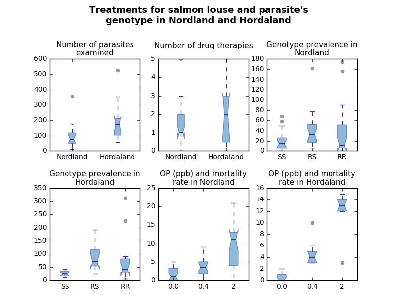

```python
print("            Fig.3 | Box-plot exercise - final figure")
display(Image('C://Users//Dar1//Documents//she_codes//python//box_plot_fig.png',
              width=500, height=500))
```